# SYNTHÈSE : ACTIONS ÉDUCATIVES, CULTURELLES & SOCIALES

## ACTION CULTURELLE SYNTHESE

### Evolution du nombre d'actions par types de publics ciblés

[output not shown]

### Evolution du nombre de personnes touchés par type de publics ciblés

[output not shown]

### Evolution du nombre de personnes touchées par type d'action culturelle

| Année Type d'action | Estimation Total Personnes touchées 2023 | Estimation Total Personnes touchées 2024 | Estimation Total Personnes touchées 2025 | Estimation Total Personnes touchées 2026 | Estimation Total Personnes touchées Total |
| --- | --- | --- | --- | --- | --- |
| Atelier | 913 | 1009 | 1257 | 557 | 3736 |
| Atelier d'écriture | 0 | 51 | 116 | 0 | 167 |
| Atelier informatique | 143 | 65 | 136 | 68 | 412 |
| Autre | 0 | 105 | 25 | 25 | 155 |
| Club lecture | 121 | 87 | 99 | 86 | 393 |
| Concert | 662 | 583 | 589 | 319 | 2153 |
| Conférence | 712 | 642 | 350 | 56 | 1760 |
| Danse | 0 | 0 | 0 | 0 | 0 |
| Diffusion | 0 | 5 | 50 | 0 | 55 |
| Exposition | 263 | 65 | 561 | 21 | 910 |
| Jeux | 320 | 318 | 217 | 98 | 953 |
| Jeux-vidéo | 724 | 793 | 814 | 268 | 2599 |
| Lecture | 849 | 4647 | 4538 | 246 | 10280 |
| Projection | 374 | 333 | 468 | 213 | 1388 |
| Rencontre | 182 | 130 | 204 | 255 | 771 |
| Spectacle | 672 | 835 | 486 | 644 | 2637 |
| Séance de contes | 272 | 172 | 145 | 0 | 589 |
| Vente | 2527 | 2096 | 35 | 0 | 4658 |
| Total | 8734 | 11936 | 10090 | 2856 | 33616 |

### Evolution du nombre d'actions par type d'action culturelle

| Année Type d'action | Nb actions 2023 | Nb actions 2024 | Nb actions 2025 | Nb actions 2026 | Nb actions Total |
| --- | --- | --- | --- | --- | --- |
| Atelier | 40 | 55 | 62 | 72 | 229 |
| Atelier d'écriture | 0 | 6 | 8 | 3 | 17 |
| Atelier informatique | 20 | 9 | 13 | 20 | 62 |
| Autre | 1 | 2 | 2 | 6 | 11 |
| Club lecture | 9 | 7 | 7 | 6 | 29 |
| Concert | 14 | 12 | 10 | 10 | 46 |
| Conférence | 18 | 25 | 11 | 4 | 58 |
| Danse | 0 | 0 | 0 | 1 | 1 |
| Diffusion | 0 | 1 | 1 | 0 | 2 |
| Exposition | 4 | 3 | 9 | 15 | 31 |
| Jeux | 14 | 10 | 15 | 16 | 55 |
| Jeux-vidéo | 22 | 26 | 27 | 38 | 113 |
| Lecture | 20 | 131 | 143 | 14 | 308 |
| Projection | 10 | 6 | 13 | 9 | 38 |
| Rencontre | 11 | 11 | 10 | 15 | 47 |
| Spectacle | 10 | 16 | 10 | 13 | 49 |
| Séance de contes | 10 | 7 | 5 | 3 | 25 |
| Vente | 1 | 3 | 1 | 0 | 5 |
| Total | 204 | 330 | 347 | 245 | 1126 |

## SYNTHÈSE ACTIONS EDUCATIVES & SOCIALES

## FOCUS : les Collectivités

Secteurs

- [x] Nb de malles prêtées par secteur
- [x] Nb de profs touchés par secteur
- [ ] Nb d'élève touchés par secteur (revoir avec Collectivités, la méthode de calcul)
- [x] (Evolution sur deux ans)

Quartier

- [x] Nb de malles prêtées par quartier
- [x] Nb de profs touchés par quartier
- [ ] Nb d'élève touchés par quartier (revoir avec Collectivités, la méthode de calcul)
- [x] (Evolution sur deux ans)

Ecoles

- [x] Nb de malles prêtées par écoles
- [x] Nb de profs touchés par école
- [ ] Nb d'élève touchés par école (revoir avec Collectivités, la méthode de calcul)
- [x] (Evolution sur deux ans)

Que représentent les structures non-scolaires sur le total de structure totales touchées, en terme de

- [x] Nb de malles envoyées ?
- [ ] Niveau si scolaire (pas assez clair)

Détail Nb de malles envoyées par types de structure : -CS

- [x] Centre médico-social
- [x] Petite Enfance

### Nb de malles prétées par secteur

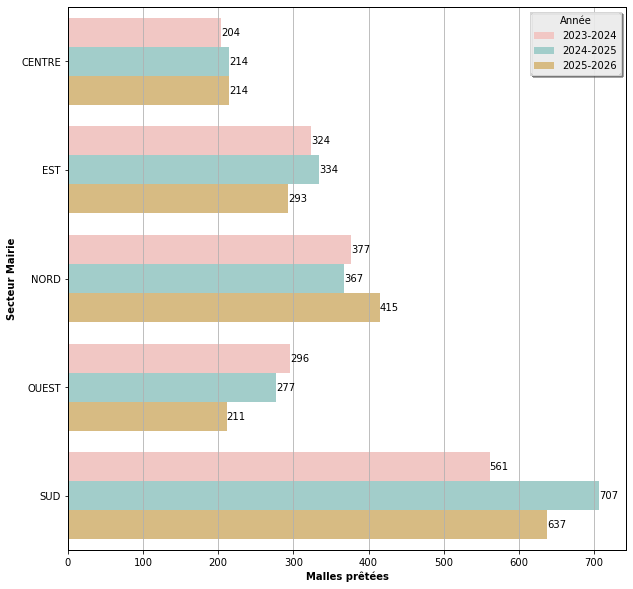

### Nb de malles prêtées par quartier

| Année scolaire Quartier historique | 2023-2024 | 2024-2025 | 2025-2026 |
| --- | --- | --- | --- |
| ALMA GARE | 18 | 14 | 10 |
| ANSEELE MOTTE BOSSUT | 70 | 82 | 96 |
| BARBIEUX | 123 | 151 | 122 |
| CENTRE VILLE | 47 | 45 | 41 |
| CUL DE FOUR | 51 | 45 | 33 |
| EDOUARD VAILLANT | 27 | 14 | 14 |
| ENTREPONT | 5 | 5 | 0 |
| EPEULE | 79 | 81 | 67 |
| FOSSE AUX CHENES | 16 | 15 | 24 |
| FRATERNITE | 14 | 11 | 16 |
| FRESNOY MACKELLERIE | 127 | 100 | 80 |
| HAUTS CHAMPS | 10 | 15 | 13 |
| HOMMELET | 227 | 218 | 272 |
| HUTIN - ORAN - CARTIGNY | 60 | 70 | 76 |
| MOULIN | 71 | 52 | 56 |
| NATIONS UNIES | 47 | 45 | 41 |
| NOUVEAU ROUBAIX | 183 | 267 | 219 |
| PILE | 99 | 66 | 81 |
| POTENNERIE | 187 | 250 | 249 |
| STE ELISABETH | 45 | 39 | 30 |
| TRICHON | 90 | 96 | 64 |
| TROIS PONTS | 166 | 218 | 166 |

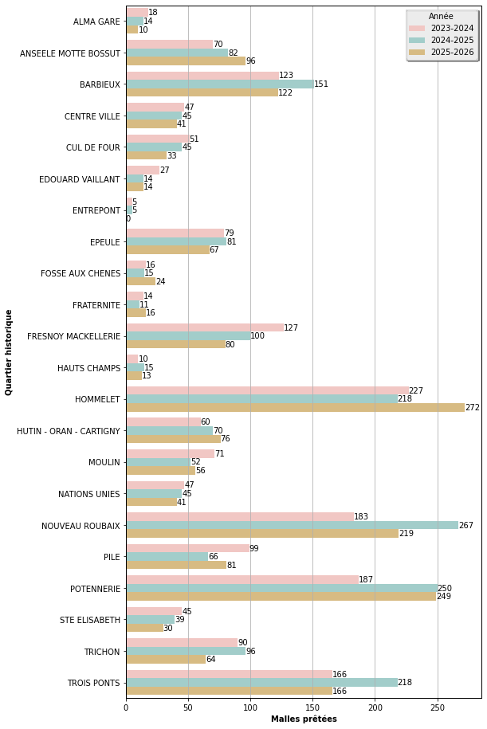

|  | Quartier historique | Année | Malles prêtées |
| --- | --- | --- | --- |
| 0 | ALMA GARE | 2023-2024 | 18 |
| 1 | ANSEELE MOTTE BOSSUT | 2023-2024 | 70 |
| 2 | BARBIEUX | 2023-2024 | 123 |
| 3 | CENTRE VILLE | 2023-2024 | 47 |
| 4 | CUL DE FOUR | 2023-2024 | 51 |
| ... | ... | ... | ... |
| 61 | PILE | 2025-2026 | 81 |
| 62 | POTENNERIE | 2025-2026 | 249 |
| 63 | STE ELISABETH | 2025-2026 | 30 |
| 64 | TRICHON | 2025-2026 | 64 |
| 65 | TROIS PONTS | 2025-2026 | 166 |

66 rows × 3 columns

### Cartographie des malles prêtées

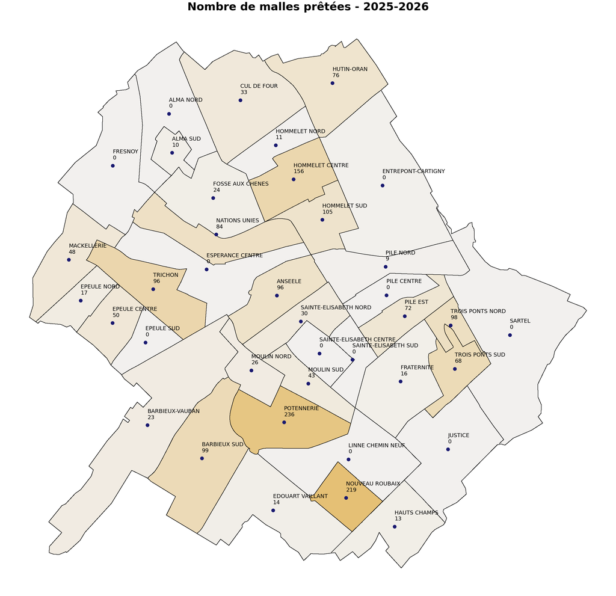

### Nb de malles prêtés par écoles

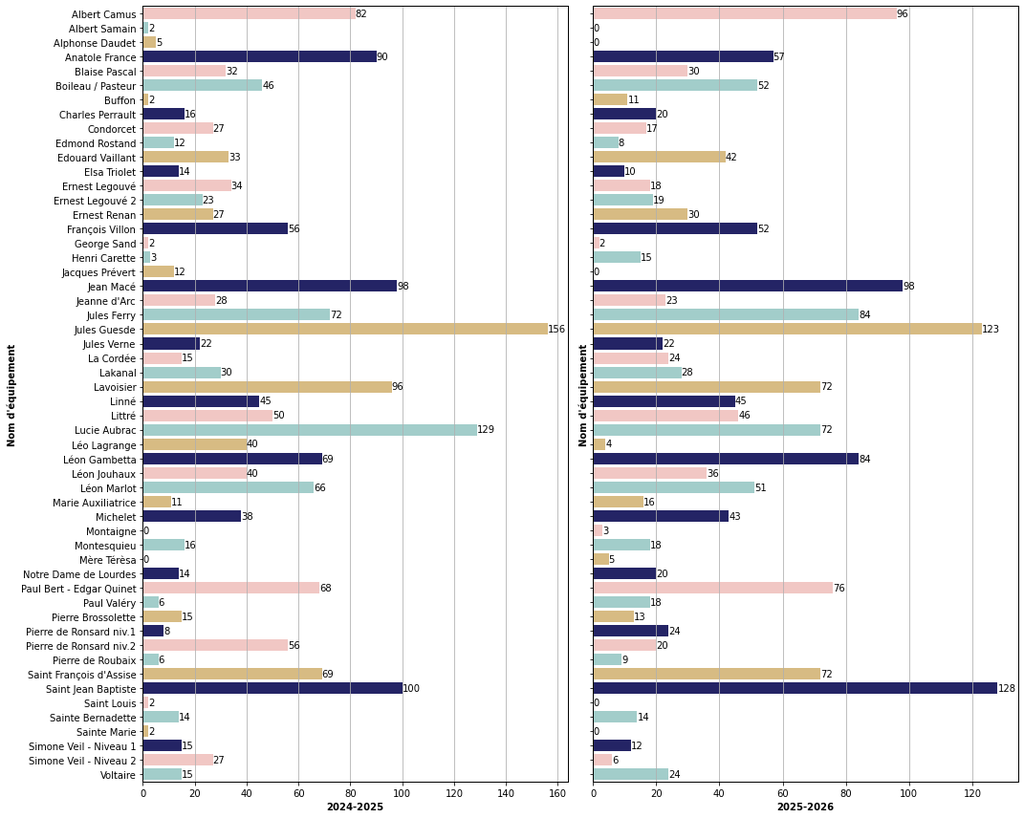

##### Tendance des prêts de malles aux écoles / Année scolaire (2024-2025 => 2025-2026)

> Proposition de regroupement par tendances en fonction de l'évolution en % :
> - Entre +75% et + : en extrême hausse
> - Entre +50% et +75% : en très forte hausse
> - Entre +25% et +50% : en forte hausse
> - Entre 0% et +25% : en hausse
> - Entre 0% et -25% : en baisse
> - Entre -25% et -50% : en forte baisse
> - Entre -50% et -75% : en très forte baisse
> - Plus de -75% : en extrême baisse

```
EN EXTRÊME HAUSSE
-------------------------------------------------------
Année scolaire    2024-2025  2025-2026   En %
Nom d'équipement
Montaigne                 0          3  100.0
Mère Térèsa               0          5  100.0
Buffon                    2         11   81.8
Henri Carette             3         15   80.0

EN TRÈS FORTE HAUSSE
-------------------------------------------------------
Année scolaire           2024-2025  2025-2026  En %
Nom d'équipement
Paul Valéry                      6         18  66.7
Pierre de Ronsard niv.1          8         24  66.7

EN FORTE HAUSSE
-------------------------------------------------------
Année scolaire         2024-2025  2025-2026  En %
Nom d'équipement
La Cordée                     15         24  37.5
Voltaire                      15         24  37.5
Pierre de Roubaix              6          9  33.3
Marie Auxiliatrice            11         16  31.2
Notre Dame de Lourdes         14         20  30.0

EN HAUSSE
-------------------------------------------------------
Année scolaire            2024-2025  2025-2026  En %
Nom d'équipement
Saint Jean Baptiste             100        128  21.9
Edouard Vaillant                 33         42  21.4
Charles Perrault                 16         20  20.0
Léon Gambetta                    69         84  17.9
Albert Camus                     82         96  14.6
Jules Ferry                      72         84  14.3
Michelet                         38         43  11.6
Boileau / Pasteur                46         52  11.5
Montesquieu                      16         18  11.1
Paul Bert - Edgar Quinet         68         76  10.5
```

[output cut: 38 more lines]

```

EN EXTRÊME BAISSE
-------------------------------------------------------
Année scolaire           2024-2025  2025-2026   En %
Nom d'équipement
Lucie Aubrac                   129         72  -79.2
Ernest Legouvé                  34         18  -88.9
Pierre de Ronsard niv.2         56         20 -180.0
Simone Veil - Niveau 2          27          6 -350.0
Léo Lagrange                    40          4 -900.0
Albert Samain                    2          0   -inf
Alphonse Daudet                  5          0   -inf
Jacques Prévert                 12          0   -inf
Saint Louis                      2          0   -inf
Sainte Marie                     2          0   -inf
```

### Nb de profs distincts touchés par école

| Année scolaire Nom d'équipement | 2023-2024 | 2024-2025 | 2025-2026 |
| --- | --- | --- | --- |
| Albert Camus | 11 | 8 | 11 |
| Albert Samain | 2 | 1 | 0 |
| Alphonse Daudet | 3 | 1 | 0 |
| Anatole France | 5 | 7 | 6 |
| Blaise Pascal | 8 | 4 | 3 |
| Boileau / Pasteur | 9 | 10 | 10 |
| Buffon | 4 | 2 | 8 |
| Charles Perrault | 1 | 1 | 1 |
| Condorcet | 6 | 5 | 5 |
| Edmond Rostand | 4 | 2 | 4 |
| Edouard Vaillant | 5 | 2 | 3 |
| Elsa Triolet | 7 | 6 | 4 |
| Ernest Legouvé | 9 | 5 | 4 |
| Ernest Legouvé 2 | 2 | 4 | 5 |
| Ernest Renan | 7 | 2 | 2 |
| François Villon | 8 | 5 | 7 |
| George Sand | 1 | 1 | 1 |
| Henri Carette | 1 | 1 | 2 |
| Jacques Prévert | 0 | 1 | 0 |
| Jean Macé | 11 | 10 | 9 |
| Jeanne d'Arc | 3 | 6 | 7 |
| Jules Ferry | 6 | 7 | 7 |
| Jules Guesde | 8 | 12 | 8 |
| Jules Verne | 2 | 3 | 6 |
| La Cordée | 1 | 1 | 1 |
| Lakanal | 3 | 5 | 5 |
| Lavoisier | 14 | 9 | 5 |
| Linné | 3 | 3 | 4 |
| Littré | 9 | 5 | 5 |
| Lucie Aubrac | 8 | 11 | 7 |
| Léo Lagrange | 3 | 6 | 1 |
| Léon Gambetta | 7 | 6 | 8 |
| Léon Jouhaux | 3 | 3 | 2 |
| Léon Marlot | 4 | 4 | 5 |
| Marie Auxiliatrice | 4 | 3 | 3 |
| Michelet | 13 | 8 | 8 |
| Montaigne | 1 | 0 | 1 |
| Montesquieu | 3 | 4 | 3 |
| Mère Térèsa | 2 | 0 | 2 |
| Notre Dame de Lourdes | 4 | 2 | 2 |
| Paul Bert - Edgar Quinet | 11 | 7 | 11 |
| Paul Valéry | 2 | 1 | 2 |
| Pierre Brossolette | 3 | 6 | 3 |
| Pierre de Ronsard niv.1 | 1 | 2 | 2 |
| Pierre de Ronsard niv.2 | 2 | 6 | 1 |
| Pierre de Roubaix | 2 | 2 | 3 |
| Saint François d'Assise | 6 | 7 | 5 |
| Saint Jean Baptiste | 1 | 9 | 8 |
| Saint Louis | 0 | 1 | 0 |
| Sainte Bernadette | 7 | 4 | 3 |
| Sainte Marie | 5 | 1 | 0 |
| Simone Veil - Niveau 1 | 2 | 1 | 1 |
| Simone Veil - Niveau 2 | 4 | 3 | 2 |
| Voltaire | 6 | 5 | 7 |

### Nb d'élèves touchés par école

> - Si prêt d'une Marmothèque au cours de l'année scolaire : on compte le total effectif maternelle
> - Si prêt d'une BCD au cours de l'année scolaire : on compte le total effectif de l'école
> - Si ni prêt de Marmothèque ou BCD au cours de l'année scolaire, on applique la formule suivante :  
>   `nb prêts profs distincts x effectif théorique d'une classe (20)`

[figure not shown]

### Que représentent le nombre de structures non-scolaires ?

#### Par nb de malles prêtés

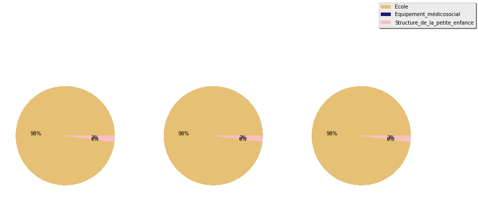

[output not shown]

#### Par niveau

| Type de structure_x Niveau si école | Association | Centre_social | Ecole | Lycée | Total |
| --- | --- | --- | --- | --- | --- |
| 2de | 0 | 0 | 0 | 1 | 1 |
| CE1 | 0 | 0 | 555 | 0 | 555 |
| CE1 / CE2 | 0 | 0 | 128 | 0 | 128 |
| CE2 | 0 | 0 | 493 | 0 | 493 |
| CE2 / CM1 | 0 | 0 | 119 | 0 | 119 |
| CE2 / CM2 | 0 | 0 | 3 | 0 | 3 |
| CM1 | 0 | 0 | 531 | 0 | 531 |
| CM1 / CM2 | 0 | 0 | 294 | 0 | 294 |
| CM1 / CM3 | 0 | 0 | 2 | 0 | 2 |
| CM2 | 0 | 0 | 230 | 0 | 230 |
| CP | 0 | 0 | 860 | 0 | 860 |
| CP / CE1 | 0 | 0 | 63 | 0 | 63 |
| Classe Ulis | 0 | 0 | 177 | 1 | 178 |
| Classe passerelle | 0 | 0 | 119 | 0 | 119 |
| GS | 0 | 0 | 707 | 0 | 707 |
| GS / CP | 0 | 0 | 10 | 0 | 10 |
| MS | 0 | 0 | 127 | 0 | 127 |
| MS / GS | 0 | 0 | 54 | 0 | 54 |
| Maternelle (tout niveau) | 0 | 1 | 186 | 0 | 187 |
| PS | 1 | 0 | 308 | 0 | 309 |
| PS / MS | 0 | 0 | 361 | 0 | 361 |
| TPS / MS | 0 | 0 | 36 | 0 | 36 |
| TPS / PS | 0 | 0 | 21 | 0 | 21 |
| UPE2A | 0 | 0 | 16 | 0 | 16 |
| Total | 1 | 1 | 5400 | 2 | 5404 |

# STATS : DEMANDE DU SERVICE DÉVELOPPEMENT DES PUBLICS

## A) Que représente les publics touchés pour le Pôle développement des publics ?

### A1) Via des actions de médiation spécifique

> **Méthode de calcule** : Pour `Type de structure` les valeurs `Centre social`, `Ecole` et `Structure_de_la_petite_enfance`, puis on filtre pour ne garder que les porteurs de projets de l'équipe DévPub

| Année scolaire Type de structure | Estimation Total Personnes touchées 2023-2024 | Estimation Total Personnes touchées 2024-2025 | Estimation Total Personnes touchées 2025-2026 |
| --- | --- | --- | --- |
| Centre_social | 266.0 | 313.0 | 10.0 |
| Ecole | 344.0 | 877.0 | 537.0 |
| Structure_de_la_petite_enfance | 69.0 | 122.0 | 212.0 |

```
Type de structure
Centre_social                     313.0
Ecole                             877.0
Structure_de_la_petite_enfance    122.0
Name: (Estimation Total Personnes touchées, 2024-2025), dtype: float64
```

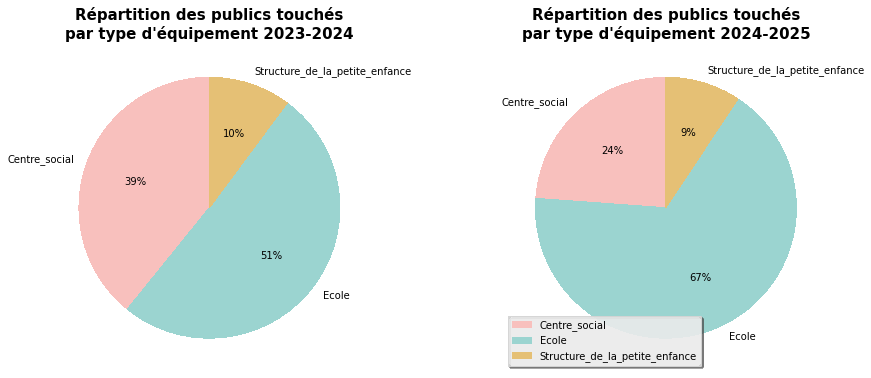

#### Focus sur les AL : (effet de réseau)

| Type de structure Année scolaire | Nb de classes touchées si public scolaire Centre_de_loisirs | Nb de classes touchées si public scolaire Ecole | Nb de classes touchées si public scolaire Structure_de_la_petite_enfance |
| --- | --- | --- | --- |
| 2022-2023 | 0 | 40 | 0 |
| 2023-2024 | 0 | 40 | 0 |
| 2024-2025 | 0 | 40 | 0 |
| 2025-2026 | 0 | 32 | 0 |

| Année scolaire Type de structure | Estimation Total Personnes touchées 2022-2023 | Estimation Total Personnes touchées 2023-2024 | Estimation Total Personnes touchées 2024-2025 | Estimation Total Personnes touchées 2025-2026 |
| --- | --- | --- | --- | --- |
| Centre_de_loisirs | 50 | 50 | 50 | 50 |
| Ecole | 562 | 562 | 562 | 562 |
| Structure_de_la_petite_enfance | 62 | 62 | 62 | 62 |

| Année scolaire Type de structure | Nb d'accueil ou séance 2022-2023 | Nb d'accueil ou séance 2023-2024 | Nb d'accueil ou séance 2024-2025 | Nb d'accueil ou séance 2025-2026 |
| --- | --- | --- | --- | --- |
| Centre_de_loisirs | 144 | 144 | 144 | 144 |
| Ecole | 2040 | 2040 | 2040 | 1968 |
| Structure_de_la_petite_enfance | 72 | 72 | 72 | 72 |

#### Focus sur les publics du champ social

> Parmi toutes les valeurs possibles du champ `Type de public` :

```
Enfant Scolaires (3-12 ans)                     2930
Tout public                                      410
Adultes                                          302
Enfants                                          287
Petite enfance (0-3 ans)                         195
Adolescents (12-18 ans)                          135
Petite enfance                                   101
Enfant hors-scolaire (3-12 ans)                   56
Adultes (26-64 ans)                               39
Familles                                          25
Populations allophones                            25
Public captif de la structure partenaire          24
Adolescents                                       15
Jeunes (18-25 ans)                                14
Personnes âgées (65 ans et plus)                   9
Etudiants, apprentis                               3
Populations en situation d'insertion sociale       3
tout public                                        2
Classe Ulysse                                      1
adultes                                            1
Personnes en situation de handicap                 1
Name: Type de public, dtype: int64
```

> Je n'ai gardé que les valeurs suivantes :

```
Enfant hors-scolaire (3-12 ans)
Public captif de la structure partenaire
Populations allophones
Personnes âgées (65 ans et plus)
Populations en situation d'insertion sociale
Personnes en situation de handicap
Classe Ulysse
```

| Année scolaire Type de public | 2022-2023 | 2023-2024 | 2024-2025 | 2025-2026 |
| --- | --- | --- | --- | --- |
| Enfant hors-scolaire (3-12 ans) | 50 | 2366 | 548 | 52 |
| Public captif de la structure partenaire | 0 | 271 | 83 | 0 |
| Populations allophones | 0 | 92 | 256 | 14 |
| Personnes âgées (65 ans et plus) | 0 | 62 | 33 | 0 |
| Populations en situation d'insertion sociale | 0 | 14 | 13 | 0 |
| Personnes en situation de handicap | 0 | 16 | 0 | 0 |
| Classe Ulysse | 0 | 0 | 10 | 0 |

### A2) Via des services Hors-les-murs (desserte doc, bibliobus, collectivités)

> Ces données ne sont pas présentes dans le tableau de suivi AECS et nécessite une extraction des données de Koha.

> **Que compte-t-on exactement ?** Le nombre d'emprunteurs pour ces services ?

## B) Quel impact sur les scolaires ?

> Cartographie

> Pour réaliser la cartographie, je vais devoir associer pour chaque nom d'établissement un identifiant iris
- [ ] Essayer de créer une méthode pour récupérer la liste de tous les établissements (laisser la possibilitée de choisir tous les établissements ou uniquement ceux concernés par les actions aecs)
- [x] Trouver un moyen de récupérer soit le code iris soit le nom du quartier

### B0 - Quelles évolution du nb d'actions et du nb de publics touchés pour les visites de la classe ?

- [x] Pour chaque structure scolaire, ajouter un code IRIS
- [x] Réaliser une carto si possible

#### Répartition du Total Personnes touchées par secteur

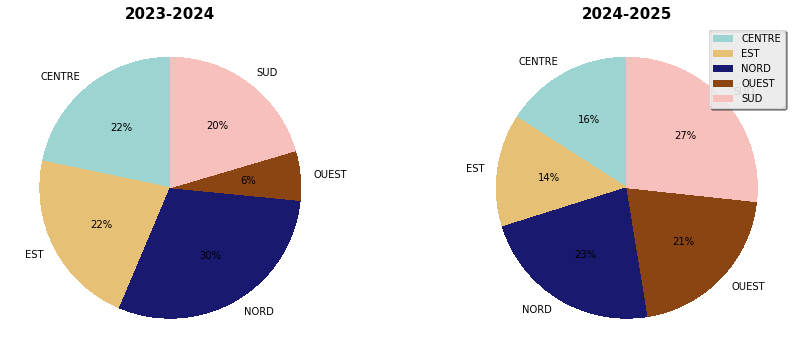

#### Répartition du Nb Total de séances par secteur

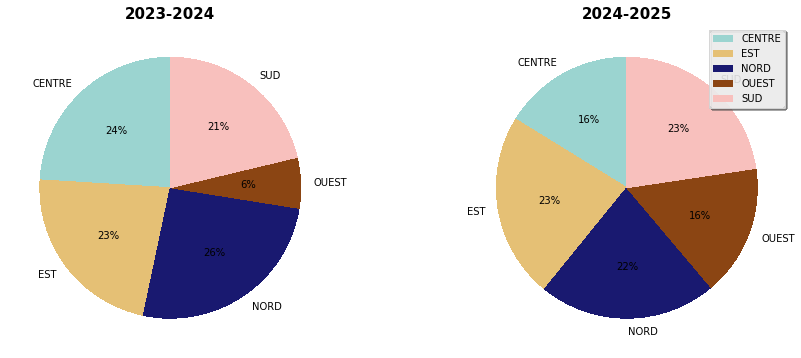

| Secteur Mairie | Année scolaire Quartier historique | Estimation Total Personnes touchées 2023-2024 | Estimation Total Personnes touchées 2024-2025 | Nb d'accueil ou séance 2023-2024 | Nb d'accueil ou séance 2024-2025 |
| --- | --- | --- | --- | --- | --- |
| CENTRE | ANSEELE MOTTE BOSSUT | 916 | 236 | 52 | 16 |
|  | CENTRE VILLE | 159 | 126 | 7 | 16 |
|  | MOULIN | 51 | 40 | 3 | 5 |
|  | NATIONS UNIES | 159 | 126 | 7 | 16 |
| EST | FRATERNITE | 0 | 20 | 0 | 3 |
|  | PILE | 492 | 33 | 22 | 6 |
|  | STE ELISABETH | 246 | 72 | 15 | 6 |
|  | TROIS PONTS | 560 | 336 | 28 | 60 |
| NORD | ALMA GARE | 56 | 30 | 2 | 6 |
|  | CUL DE FOUR | 804 | 234 | 30 | 21 |
|  | FOSSE AUX CHENES | 243 | 115 | 9 | 17 |
|  | HOMMELET | 495 | 343 | 25 | 22 |
|  | HUTIN - ORAN - CARTIGNY | 166 | 32 | 8 | 6 |
| OUEST | EPEULE | 131 | 274 | 7 | 12 |
|  | FRESNOY MACKELLERIE | 104 | 172 | 5 | 15 |
|  | TRICHON | 128 | 240 | 6 | 26 |
| SUD | BARBIEUX | 396 | 153 | 15 | 12 |
|  | EDOUARD VAILLANT | 25 | 40 | 1 | 3 |
|  | MOULIN | 123 | 36 | 6 | 2 |
|  | NOUVEAU ROUBAIX | 438 | 360 | 24 | 36 |
|  | POTENNERIE | 227 | 296 | 15 | 21 |

#### Visites de classes - Estimation de la population touchée par quartiers

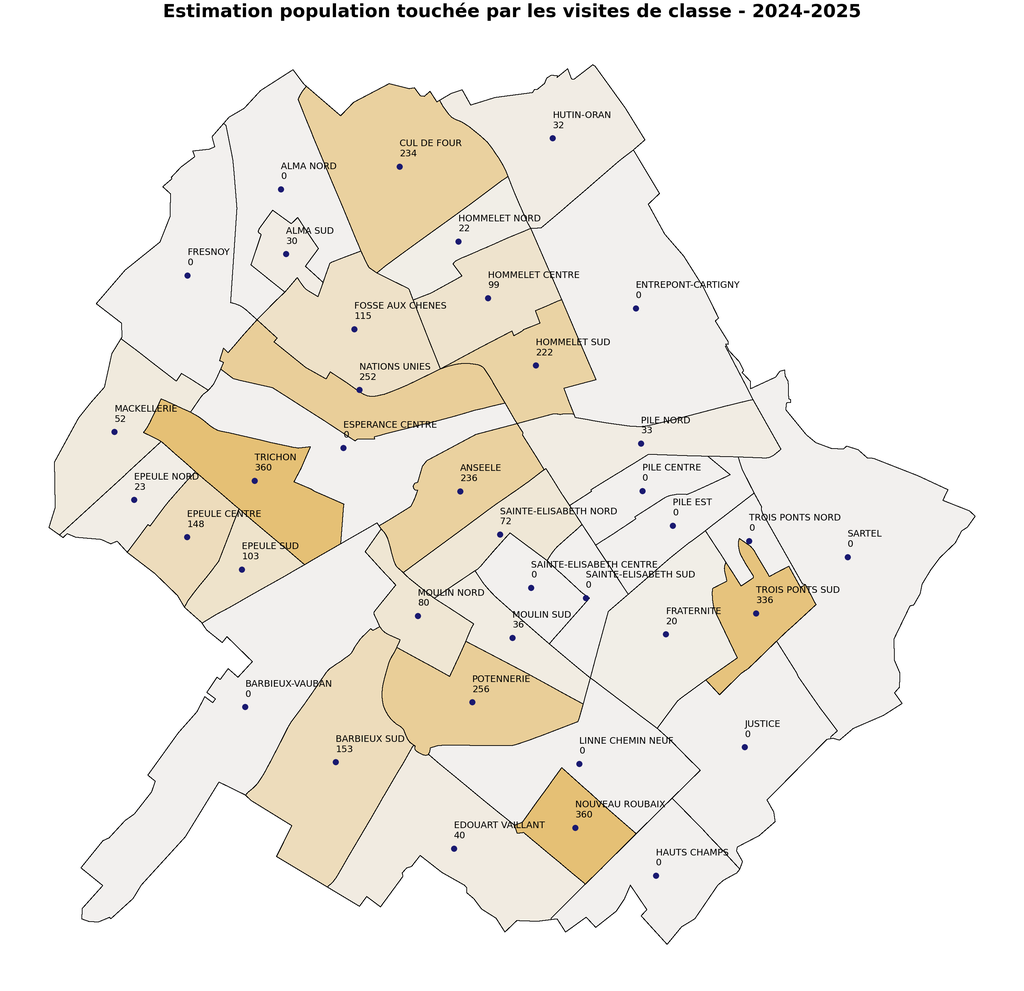

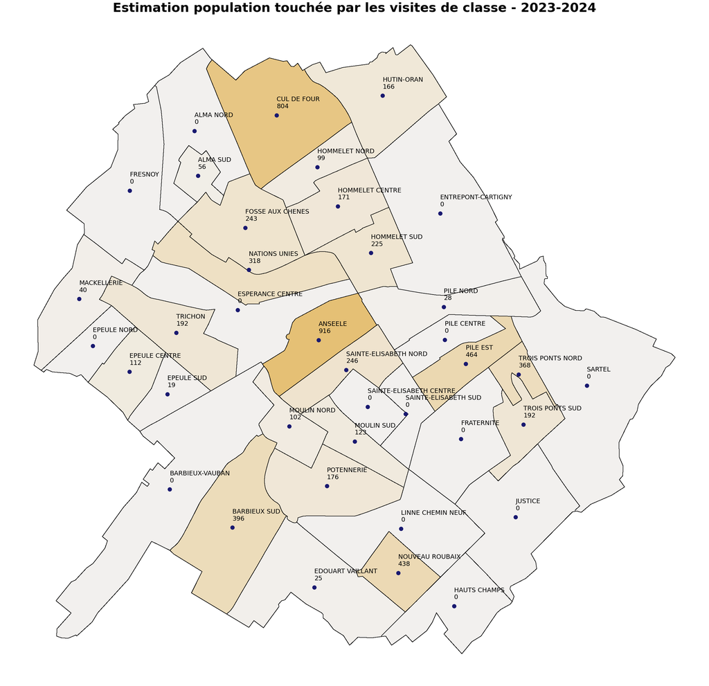

#### Visites de classes - Nb de séances par quartiers

[figure not shown]

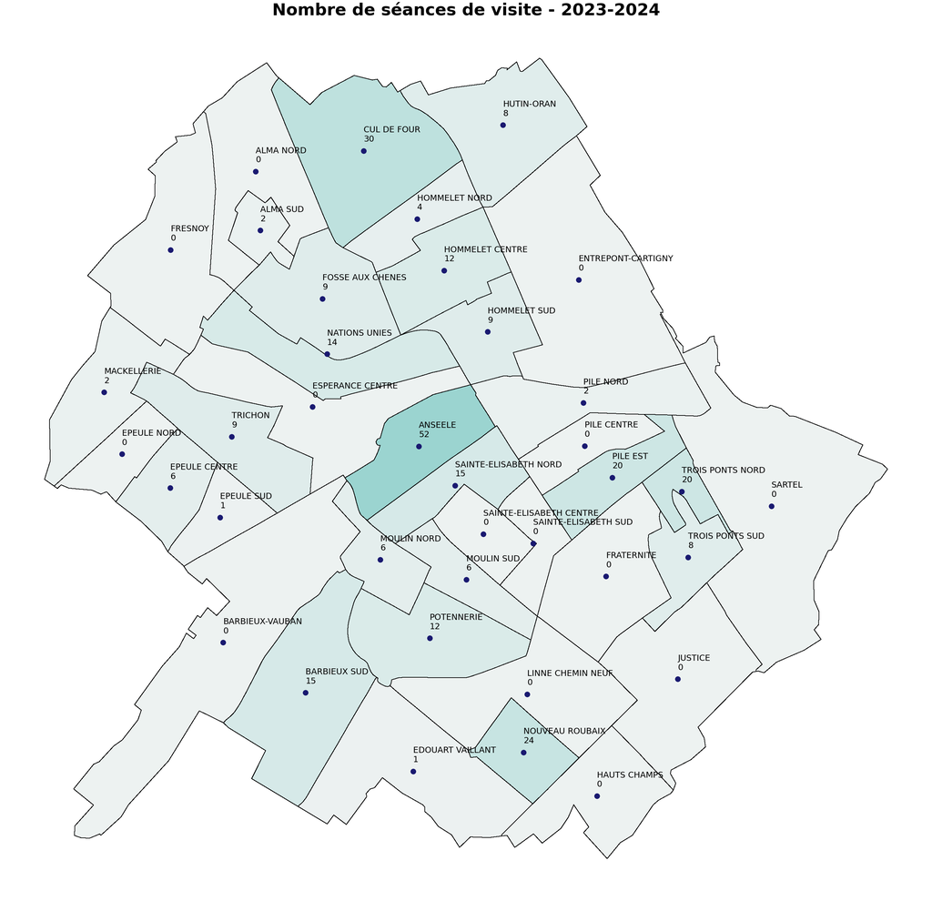

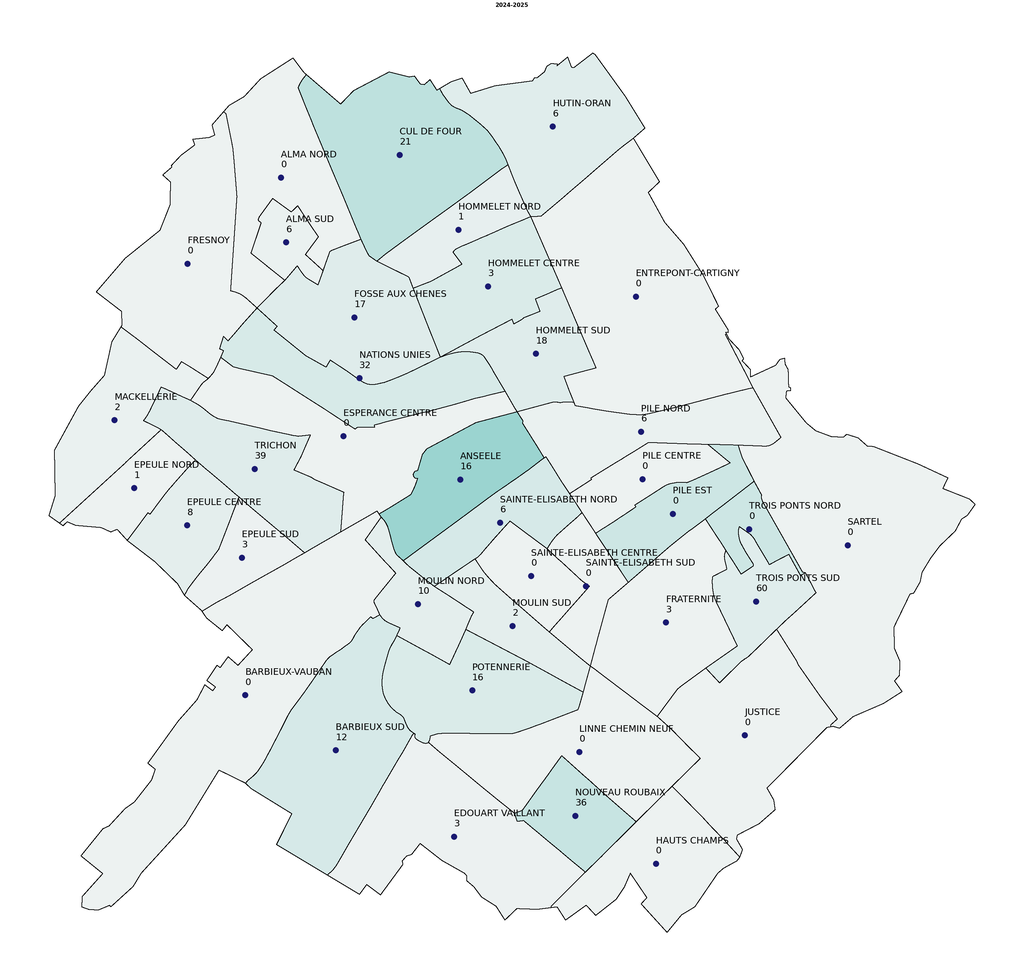

### B1 - Taux de pénétration accueil des visites de classe

> (nombre d'élèves touchés / Nb d'élèves par IRIS)
- [ ] Récuper le `Nb d'élèves à Roubaix`

### B2 - Taux de pénétration du service aux collectivités

> (Nombre de classes accueillies / nombre de classes à Roubaix)
- [ ] Récuper le `Nb de classes` à Roubaix

## C) Poids du Hors-les-murs dans la répartition des publics touchés par les AECS

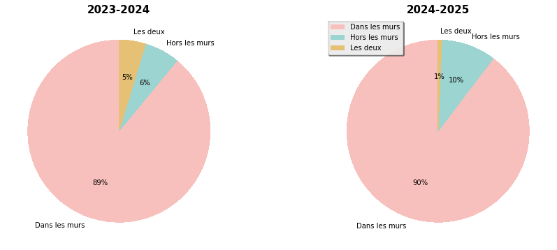

| Année scolaire Lieu | 2022-2023 | 2023-2024 | 2024-2025 | 2025-2026 |
| --- | --- | --- | --- | --- |
| Dans les murs | 3728 | 19040 | 17519 | 6880 |
| Hors les murs | 674 | 1338 | 1887 | 1252 |
| Les deux | 0 | 1004 | 130 | 0 |

## D) Les partenaires de la médiathèque

- [x] Pour les partenariats retenir la liste des types de structure
- [x] Exclure les accueils et visites de classes

| En partenariat avec | Année scolaire Type de structure | Estimation Total Personnes touchées 2022-2023 | Estimation Total Personnes touchées 2023-2024 | Estimation Total Personnes touchées 2024-2025 | Estimation Total Personnes touchées 2025-2026 | Nb actions 2022-2023 | Nb actions 2023-2024 | Nb actions 2024-2025 | Nb actions 2025-2026 |
| --- | --- | --- | --- | --- | --- | --- | --- | --- | --- |
| Autre_institution | Centre_de_loisirs | 50 | 62 | 50 | 50 | 1 | 4 | 6 | 4 |
|  | Centre_social | 0 | 332 | 313 | 10 | 0 | 26 | 32 | 6 |
|  | Equipement_médicosocial | 0 | 40 | 22 | 14 | 0 | 7 | 6 | 5 |
|  | Maison_de_retraite | 0 | 40 | 43 | 0 | 0 | 4 | 4 | 0 |
|  | Service_emploi_et_formation | 0 | 61 | 133 | 0 | 0 | 5 | 11 | 0 |
|  | Structure_de_la_petite_enfance | 62 | 131 | 184 | 274 | 3 | 51 | 56 | 56 |
| Equipement_culturel | Centre_culturel | 94 | 464 | 53 | 45 | 3 | 5 | 4 | 1 |
| Etablissement_scolaire | Collège | 0 | 490 | 506 | 71 | 0 | 7 | 8 | 3 |
|  | Ecole | 562 | 1025 | 1511 | 1099 | 5 | 895 | 902 | 855 |
|  | Lycée | 0 | 30 | 209 | 85 | 0 | 2 | 10 | 6 |
|  | Supérieur | 0 | 207 | 163 | 0 | 0 | 7 | 7 | 0 |
| Structure_associative | Association | 459 | 586 | 856 | 379 | 10 | 35 | 27 | 22 |

> Méthode de calcul : Pour le calcul des publics touchés par type de structure, j'ai gardé toutes les feuilles sauf celle des visites de classe.

## E) Poids de l'EMI & lecture dans les projets avec les scolaires